# ANALYZING THE EFFECT OF VIOLENT VIDEO GAME PLAY ON MATE VALUE AND OTHER MATING RELATED VARIABLES

## Univariate Tests

```r
summary.aov(MANOVA1)
```

```
##  Response MV2Average :
##                           Df Sum Sq Mean Sq F value  Pr(>F)
## VorNV                      1   0.08  0.0794  0.0947 0.75844
## Age                        1   3.44  3.4443  4.1081 0.04320 *
## Selfscore                  1   1.60  1.6021  1.9109 0.16747
## Gender                     1   1.33  1.3281  1.5841 0.20876
## Averagefrequencyviolence   1   0.09  0.0882  0.1052 0.74586
## VorNV:Age                  1   1.00  1.0036  1.1971 0.27443
## VorNV:Selfscore            1   0.31  0.3063  0.3653 0.54585
## VorNV:Gender               1   0.01  0.0138  0.0164 0.89801
## Selfscore:Gender           1   3.55  3.5536  4.2385 0.04003 *
## Age:Selfscore              1   0.06  0.0576  0.0687 0.79340
## Residuals                506 424.23  0.8384
## ---
## Signif. codes:  0 '***' 0.001 '**' 0.01 '*' 0.05 '.' 0.1 ' ' 1
##
##  Response SGAAverage :
##                           Df  Sum Sq Mean Sq F value    Pr(>F)
## VorNV                      1    0.02   0.021  0.0087    0.9256
## Age                        1   49.74  49.736 20.3428 8.055e-06 ***
## Selfscore                  1    4.42   4.425  1.8098    0.1791
## Gender                     1    3.00   2.997  1.2258    0.2688
## Averagefrequencyviolence   1    0.30   0.301  0.1233    0.7257
## VorNV:Age                  1    1.83   1.833  0.7499    0.3869
## VorNV:Selfscore            1    1.67   1.669  0.6825    0.4091
## VorNV:Gender               1    0.02   0.018  0.0072    0.9324
## Selfscore:Gender           1    1.71   1.707  0.6980    0.4038
## Age:Selfscore              1    0.41   0.412  0.1687    0.6815
## Residuals                506 1237.13   2.445
## ---
## Signif. codes:  0 '***' 0.001 '**' 0.01 '*' 0.05 '.' 0.1 ' ' 1
##
##  Response SOIRTOTAL :
##                           Df Sum Sq Mean Sq F value  Pr(>F)
## VorNV                      1     13    12.9  0.0664 0.79679
## Age                        1   1179  1179.2  6.0654 0.01412 *
## Selfscore                  1    965   964.7  4.9623 0.02634 *
## Gender                     1   9301  9300.8 47.8422 1.4e-11 ***
## Averagefrequencyviolence   1    543   542.9  2.7923 0.09533 .
## VorNV:Age                  1    177   176.7  0.9091 0.34082
```

[output cut: 8 more lines]

```
##  Response MATINGMOTIVATIONtotal :
##                           Df  Sum Sq Mean Sq F value    Pr(>F)
## VorNV                      1    81.2   81.19  2.4352 0.1192662
## Age                        1    82.2   82.17  2.4644 0.1170782
## Selfscore                  1   271.6  271.56  8.1448 0.0044955 **
## Gender                     1   387.5  387.54 11.6235 0.0007032 ***
## Averagefrequencyviolence   1   888.9  888.87 26.6598 3.493e-07 ***
## VorNV:Age                  1     0.0    0.05  0.0014 0.9705598
## VorNV:Selfscore            1    48.1   48.06  1.4414 0.2304697
## VorNV:Gender               1     0.3    0.29  0.0088 0.9254020
## Selfscore:Gender           1    41.4   41.37  1.2409 0.2658281
## Age:Selfscore              1    15.9   15.89  0.4767 0.4902354
## Residuals                506 16870.7   33.34
## ---
## Signif. codes:  0 '***' 0.001 '**' 0.01 '*' 0.05 '.' 0.1 ' ' 1
```

```r
lm1<- lm(MV1Total ~ VorNV + Age + Selfscore + Gender + Averagefrequencyviolence + VorNV*Age + VorNV*Selfscore + VorNV*Gender + Selfscore*Gender + Age*Selfscore, data=data)
summary(lm1)
```

```
##
## Call:
## lm(formula = MV1Total ~ VorNV + Age + Selfscore + Gender + Averagefrequencyviolence +
##     VorNV * Age + VorNV * Selfscore + VorNV * Gender + Selfscore *
##     Gender + Age * Selfscore, data = data)
##
## Residuals:
##      Min       1Q   Median       3Q      Max
## -16.1115  -2.4884   0.6615   3.5677  10.5260
##
## Coefficients:
##                          Estimate Std. Error t value Pr(>|t|)
## (Intercept)              18.22687    2.97024   6.137  1.7e-09 ***
## VorNVV                   -1.23734    2.20463  -0.561   0.5749
## Age                      -0.01012    0.07386  -0.137   0.8911
## Selfscore                 0.87511    0.65394   1.338   0.1814
## GenderMale               -3.27358    1.56337  -2.094   0.0368 *
## Averagefrequencyviolence  0.01457    0.02560   0.569   0.5695
## VorNVV:Age                0.04829    0.04864   0.993   0.3213
## VorNVV:Selfscore         -0.11413    0.32867  -0.347   0.7286
## VorNVV:GenderMale         1.28409    0.96395   1.332   0.1834
## Selfscore:GenderMale      0.36721    0.34357   1.069   0.2857
## Age:Selfscore            -0.01138    0.01624  -0.700   0.4840
## ---
## Signif. codes:  0 '***' 0.001 '**' 0.01 '*' 0.05 '.' 0.1 ' ' 1
##
## Residual standard error: 4.948 on 506 degrees of freedom
## Multiple R-squared:  0.05002,    Adjusted R-squared:  0.03125
## F-statistic: 2.664 on 10 and 506 DF,  p-value: 0.003518
```

```r
anova(lm1)
```

```
## Analysis of Variance Table
##
## Response: MV1Total
##                           Df  Sum Sq Mean Sq F value    Pr(>F)
## VorNV                      1     0.2    0.15  0.0062 0.9373876
## Age                        1    45.2   45.20  1.8461 0.1748373
## Selfscore                  1   317.6  317.60 12.9723 0.0003473 ***
## Gender                     1   168.3  168.30  6.8742 0.0090081 **
## Averagefrequencyviolence   1     7.0    6.95  0.2839 0.5943813
## VorNV:Age                  1    28.1   28.10  1.1477 0.2845479
## VorNV:Selfscore            1     0.5    0.47  0.0193 0.8896023
## VorNV:Gender               1    27.6   27.64  1.1291 0.2884745
## Selfscore:Gender           1    45.9   45.89  1.8744 0.1715808
## Age:Selfscore              1    12.0   12.01  0.4907 0.4839559
## Residuals                506 12388.6   24.48
## ---
## Signif. codes:  0 '***' 0.001 '**' 0.01 '*' 0.05 '.' 0.1 ' ' 1
```

```r
anova(lm1, test = "Chisq")
```

```
## Analysis of Variance Table
##
## Response: MV1Total
##                           Df  Sum Sq Mean Sq F value    Pr(>F)
## VorNV                      1     0.2    0.15  0.0062 0.9373876
## Age                        1    45.2   45.20  1.8461 0.1748373
## Selfscore                  1   317.6  317.60 12.9723 0.0003473 ***
## Gender                     1   168.3  168.30  6.8742 0.0090081 **
## Averagefrequencyviolence   1     7.0    6.95  0.2839 0.5943813
## VorNV:Age                  1    28.1   28.10  1.1477 0.2845479
## VorNV:Selfscore            1     0.5    0.47  0.0193 0.8896023
## VorNV:Gender               1    27.6   27.64  1.1291 0.2884745
## Selfscore:Gender           1    45.9   45.89  1.8744 0.1715808
## Age:Selfscore              1    12.0   12.01  0.4907 0.4839559
## Residuals                506 12388.6   24.48
## ---
## Signif. codes:  0 '***' 0.001 '**' 0.01 '*' 0.05 '.' 0.1 ' ' 1
```

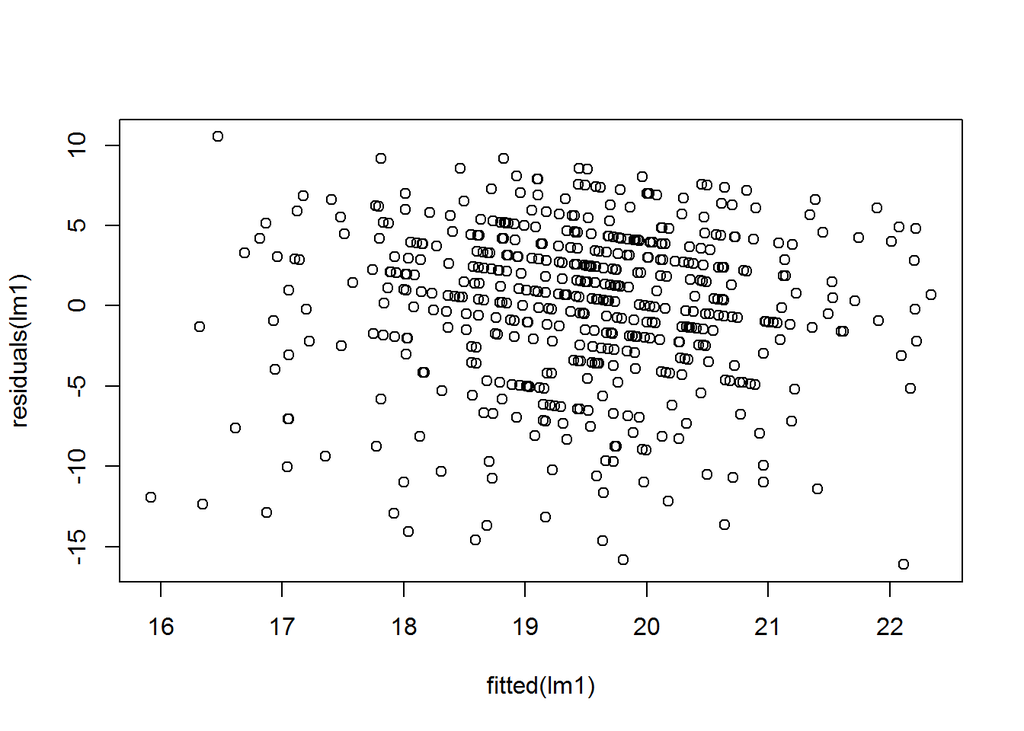

```r
plot(fitted(lm1), residuals(lm1))
```

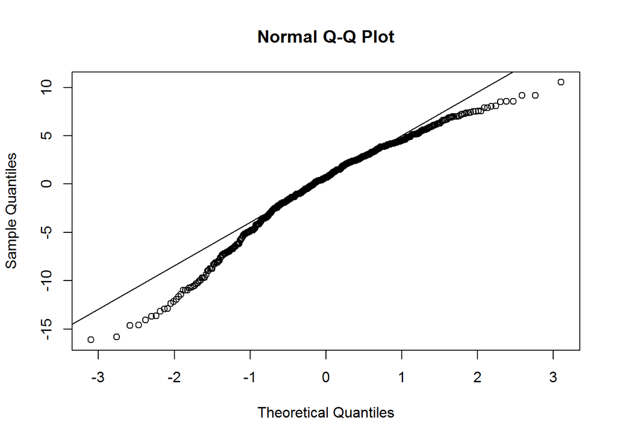

```r
qqnorm(residuals(lm1))
qqline(residuals(lm1))
```

```r
lm2<- lm(MV2Average ~ VorNV + Age + Selfscore + Gender + Averagefrequencyviolence + VorNV*Age + VorNV*Selfscore + VorNV*Gender + Selfscore*Gender + Age*Selfscore, data=data)
summary(lm2)
```

```
##
## Call:
## lm(formula = MV2Average ~ VorNV + Age + Selfscore + Gender +
##     Averagefrequencyviolence + VorNV * Age + VorNV * Selfscore +
##     VorNV * Gender + Selfscore * Gender + Age * Selfscore, data = data)
##
## Residuals:
##      Min       1Q   Median       3Q      Max
## -2.51210 -0.62222  0.09651  0.61133  2.13578
##
## Coefficients:
##                            Estimate Std. Error t value Pr(>|t|)
## (Intercept)               4.9764046  0.5496447   9.054   <2e-16 ***
## VorNVV                   -0.3979189  0.4079679  -0.975   0.3298
## Age                      -0.0175655  0.0136674  -1.285   0.1993
## Selfscore                -0.0555865  0.1210128  -0.459   0.6462
## GenderMale               -0.6192814  0.2893025  -2.141   0.0328 *
## Averagefrequencyviolence -0.0020764  0.0047374  -0.438   0.6613
## VorNVV:Age                0.0108135  0.0090014   1.201   0.2302
## VorNVV:Selfscore          0.0168180  0.0608215   0.277   0.7823
## VorNVV:GenderMale         0.0875643  0.1783793   0.491   0.6237
## Selfscore:GenderMale      0.1292421  0.0635781   2.033   0.0426 *
## Age:Selfscore             0.0007875  0.0030054   0.262   0.7934
## ---
## Signif. codes:  0 '***' 0.001 '**' 0.01 '*' 0.05 '.' 0.1 ' ' 1
##
## Residual standard error: 0.9156 on 506 degrees of freedom
## Multiple R-squared:  0.02634,    Adjusted R-squared:  0.007098
## F-statistic: 1.369 on 10 and 506 DF,  p-value: 0.1914
```

```r
anova(lm2, test = "Chisq")
```

```
## Analysis of Variance Table
##
## Response: MV2Average
##                           Df Sum Sq Mean Sq F value  Pr(>F)
## VorNV                      1   0.08  0.0794  0.0947 0.75844
## Age                        1   3.44  3.4443  4.1081 0.04320 *
## Selfscore                  1   1.60  1.6021  1.9109 0.16747
## Gender                     1   1.33  1.3281  1.5841 0.20876
## Averagefrequencyviolence   1   0.09  0.0882  0.1052 0.74586
## VorNV:Age                  1   1.00  1.0036  1.1971 0.27443
## VorNV:Selfscore            1   0.31  0.3063  0.3653 0.54585
## VorNV:Gender               1   0.01  0.0138  0.0164 0.89801
## Selfscore:Gender           1   3.55  3.5536  4.2385 0.04003 *
## Age:Selfscore              1   0.06  0.0576  0.0687 0.79340
## Residuals                506 424.23  0.8384
## ---
## Signif. codes:  0 '***' 0.001 '**' 0.01 '*' 0.05 '.' 0.1 ' ' 1
```

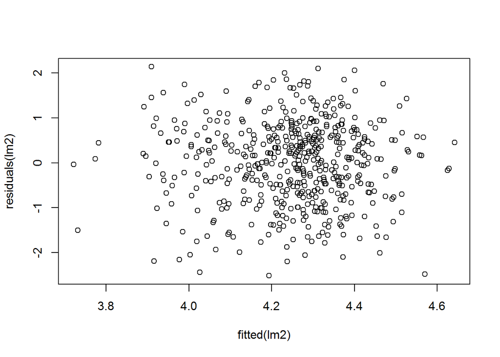

```r
plot(fitted(lm2), residuals(lm2))
```

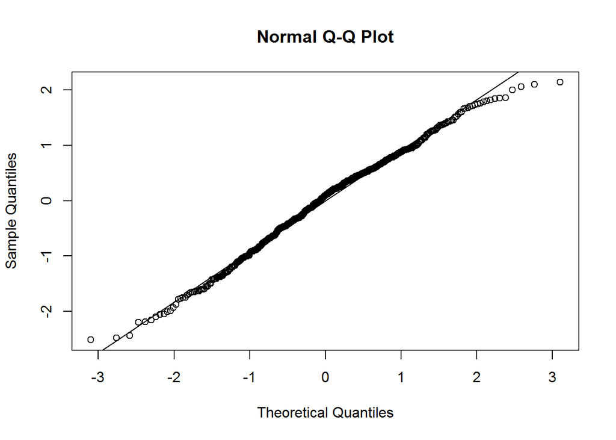

```r
qqnorm(residuals(lm2))
qqline(residuals(lm2))
```

```r
lm3<- lm(SGAAverage ~ VorNV + Age + Selfscore + Gender + Averagefrequencyviolence + VorNV*Age + VorNV*Selfscore + VorNV*Gender + Selfscore*Gender + Age*Selfscore, data=data)
summary(lm3)
```

```
##
## Call:
## lm(formula = SGAAverage ~ VorNV + Age + Selfscore + Gender +
##     Averagefrequencyviolence + VorNV * Age + VorNV * Selfscore +
##     VorNV * Gender + Selfscore * Gender + Age * Selfscore, data = data)
##
## Residuals:
##     Min      1Q  Median      3Q     Max
## -3.0588 -1.2579  0.0727  1.2474  3.5611
##
## Coefficients:
##                           Estimate Std. Error t value Pr(>|t|)
## (Intercept)               4.749061   0.938616   5.060 5.89e-07 ***
## VorNVV                   -0.046762   0.696678  -0.067   0.9465
## Age                      -0.044118   0.023340  -1.890   0.0593 .
## Selfscore                -0.012453   0.206651  -0.060   0.9520
## GenderMale               -0.250981   0.494036  -0.508   0.6117
## Averagefrequencyviolence -0.003023   0.008090  -0.374   0.7088
## VorNVV:Age                0.012257   0.015371   0.797   0.4256
## VorNVV:Selfscore         -0.097601   0.103863  -0.940   0.3478
## VorNVV:GenderMale         0.109807   0.304614   0.360   0.7186
## Selfscore:GenderMale      0.100256   0.108571   0.923   0.3562
## Age:Selfscore             0.002108   0.005132   0.411   0.6815
## ---
## Signif. codes:  0 '***' 0.001 '**' 0.01 '*' 0.05 '.' 0.1 ' ' 1
##
## Residual standard error: 1.564 on 506 degrees of freedom
## Multiple R-squared:  0.04854,    Adjusted R-squared:  0.02974
## F-statistic: 2.582 on 10 and 506 DF,  p-value: 0.004674
```

```r
anova(lm3, test = "Chisq")
```

```
## Analysis of Variance Table
##
## Response: SGAAverage
##                           Df  Sum Sq Mean Sq F value    Pr(>F)
## VorNV                      1    0.02   0.021  0.0087    0.9256
## Age                        1   49.74  49.736 20.3428 8.055e-06 ***
## Selfscore                  1    4.42   4.425  1.8098    0.1791
## Gender                     1    3.00   2.997  1.2258    0.2688
## Averagefrequencyviolence   1    0.30   0.301  0.1233    0.7257
## VorNV:Age                  1    1.83   1.833  0.7499    0.3869
## VorNV:Selfscore            1    1.67   1.669  0.6825    0.4091
## VorNV:Gender               1    0.02   0.018  0.0072    0.9324
## Selfscore:Gender           1    1.71   1.707  0.6980    0.4038
## Age:Selfscore              1    0.41   0.412  0.1687    0.6815
## Residuals                506 1237.13   2.445
## ---
## Signif. codes:  0 '***' 0.001 '**' 0.01 '*' 0.05 '.' 0.1 ' ' 1
```

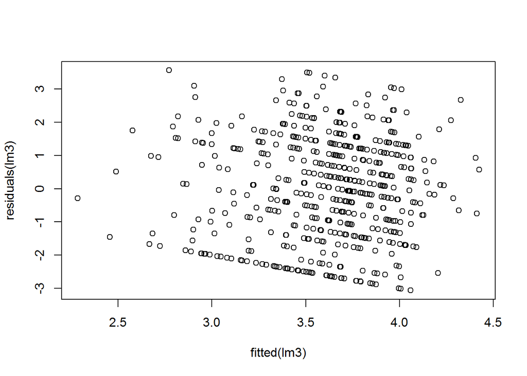

```r
plot(fitted(lm3), residuals(lm3))
```

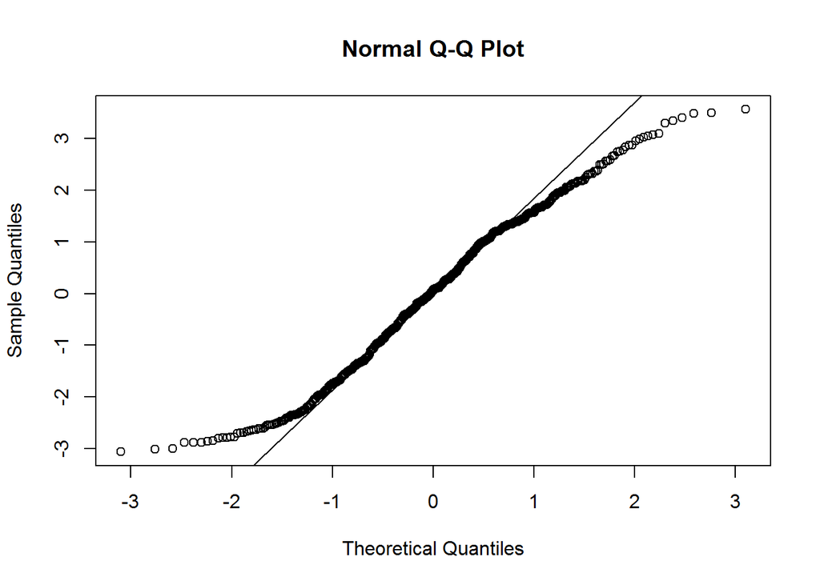

```r
qqnorm(residuals(lm3))
qqline(residuals(lm3))
```

```r
lm4<- lm(SOIRTOTAL ~ VorNV + Age + Selfscore + Gender + Averagefrequencyviolence + VorNV*Age + VorNV*Selfscore + VorNV*Gender + Selfscore*Gender + Age*Selfscore, data=data)
summary(lm4)
```

```
##
## Call:
## lm(formula = SOIRTOTAL ~ VorNV + Age + Selfscore + Gender + Averagefrequencyviolence +
##     VorNV * Age + VorNV * Selfscore + VorNV * Gender + Selfscore *
##     Gender + Age * Selfscore, data = data)
##
## Residuals:
##     Min      1Q  Median      3Q     Max
## -28.935 -11.197  -1.617   9.695  33.001
##
## Coefficients:
##                          Estimate Std. Error t value Pr(>|t|)
## (Intercept)              26.49460    8.36973   3.166  0.00164 **
## VorNVV                   11.09478    6.21235   1.786  0.07471 .
## Age                      -0.09556    0.20812  -0.459  0.64634
## Selfscore                -0.21314    1.84273  -0.116  0.90797
## GenderMale                7.61267    4.40536   1.728  0.08459 .
## Averagefrequencyviolence  0.12745    0.07214   1.767  0.07788 .
## VorNVV:Age               -0.14174    0.13707  -1.034  0.30159
## VorNVV:Selfscore         -1.73565    0.92616  -1.874  0.06150 .
## VorNVV:GenderMale        -0.16067    2.71628  -0.059  0.95286
## Selfscore:GenderMale      0.22432    0.96814   0.232  0.81686
## Age:Selfscore             0.03762    0.04576   0.822  0.41142
## ---
## Signif. codes:  0 '***' 0.001 '**' 0.01 '*' 0.05 '.' 0.1 ' ' 1
##
## Residual standard error: 13.94 on 506 degrees of freedom
## Multiple R-squared:  0.1175, Adjusted R-squared:  0.1001
## F-statistic: 6.738 on 10 and 506 DF,  p-value: 7.027e-10
```

```r
anova(lm4, test = "Chisq")
```

```
## Analysis of Variance Table
##
## Response: SOIRTOTAL
##                           Df Sum Sq Mean Sq F value  Pr(>F)
## VorNV                      1     13    12.9  0.0664 0.79679
## Age                        1   1179  1179.2  6.0654 0.01412 *
## Selfscore                  1    965   964.7  4.9623 0.02634 *
## Gender                     1   9301  9300.8 47.8422 1.4e-11 ***
## Averagefrequencyviolence   1    543   542.9  2.7923 0.09533 .
## VorNV:Age                  1    177   176.7  0.9091 0.34082
## VorNV:Selfscore            1    786   786.4  4.0450 0.04483 *
## VorNV:Gender               1      4     3.7  0.0192 0.88993
## Selfscore:Gender           1      0     0.3  0.0013 0.97112
## Age:Selfscore              1    131   131.4  0.6758 0.41142
## Residuals                506  98370   194.4
## ---
## Signif. codes:  0 '***' 0.001 '**' 0.01 '*' 0.05 '.' 0.1 ' ' 1
```

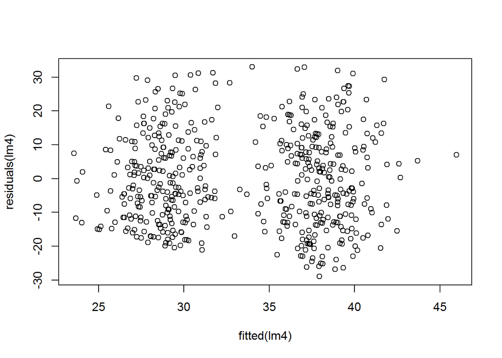

```r
plot(fitted(lm4), residuals(lm4))
```

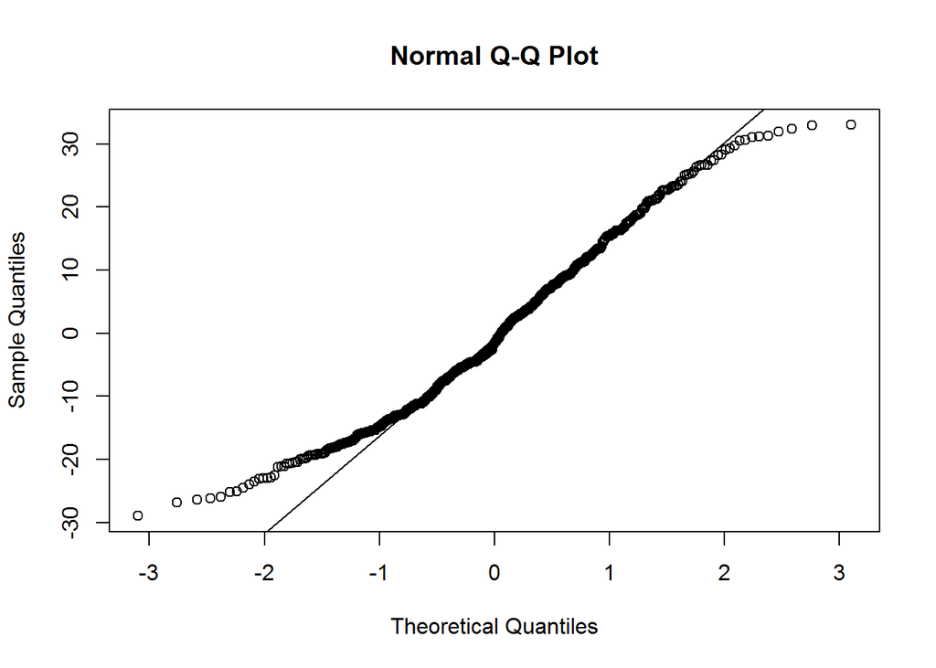

```r
qqnorm(residuals(lm4))
qqline(residuals(lm4))
```

```r
lm5<- lm(MATINGMOTIVATIONtotal ~ VorNV + Age + Selfscore + Gender + Averagefrequencyviolence + VorNV*Age + VorNV*Selfscore + VorNV*Gender + Selfscore*Gender + Age*Selfscore, data=data)
summary(lm5)
```

```
##
## Call:
## lm(formula = MATINGMOTIVATIONtotal ~ VorNV + Age + Selfscore +
##     Gender + Averagefrequencyviolence + VorNV * Age + VorNV *
##     Selfscore + VorNV * Gender + Selfscore * Gender + Age * Selfscore,
##     data = data)
##
## Residuals:
##    Min     1Q Median     3Q    Max
## -9.096 -4.594 -1.534  3.882 19.146
##
## Coefficients:
##                           Estimate Std. Error t value Pr(>|t|)
## (Intercept)               6.363518   3.466152   1.836    0.067 .
## VorNVV                    3.308617   2.572715   1.286    0.199
## Age                      -0.061526   0.086189  -0.714    0.476
## Selfscore                 0.520191   0.763127   0.682    0.496
## GenderMale               -1.098431   1.824391  -0.602    0.547
## Averagefrequencyviolence  0.153913   0.029875   5.152  3.7e-07 ***
## VorNVV:Age               -0.004349   0.056764  -0.077    0.939
## VorNVV:Selfscore         -0.357218   0.383550  -0.931    0.352
## VorNVV:GenderMale        -0.378939   1.124890  -0.337    0.736
## Selfscore:GenderMale     -0.333036   0.400934  -0.831    0.407
## Age:Selfscore             0.013086   0.018953   0.690    0.490
## ---
## Signif. codes:  0 '***' 0.001 '**' 0.01 '*' 0.05 '.' 0.1 ' ' 1
##
## Residual standard error: 5.774 on 506 degrees of freedom
## Multiple R-squared:  0.09723,    Adjusted R-squared:  0.07939
## F-statistic:  5.45 on 10 and 506 DF,  p-value: 1.065e-07
```

```r
anova(lm5, test="Chisq")
```

```
## Analysis of Variance Table
##
## Response: MATINGMOTIVATIONtotal
##                           Df  Sum Sq Mean Sq F value    Pr(>F)
## VorNV                      1    81.2   81.19  2.4352 0.1192662
## Age                        1    82.2   82.17  2.4644 0.1170782
## Selfscore                  1   271.6  271.56  8.1448 0.0044955 **
## Gender                     1   387.5  387.54 11.6235 0.0007032 ***
## Averagefrequencyviolence   1   888.9  888.87 26.6598 3.493e-07 ***
## VorNV:Age                  1     0.0    0.05  0.0014 0.9705598
## VorNV:Selfscore            1    48.1   48.06  1.4414 0.2304697
## VorNV:Gender               1     0.3    0.29  0.0088 0.9254020
## Selfscore:Gender           1    41.4   41.37  1.2409 0.2658281
## Age:Selfscore              1    15.9   15.89  0.4767 0.4902354
## Residuals                506 16870.7   33.34
## ---
## Signif. codes:  0 '***' 0.001 '**' 0.01 '*' 0.05 '.' 0.1 ' ' 1
```

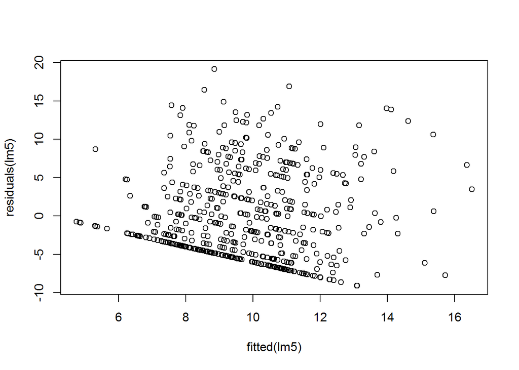

```r
plot(fitted(lm5), residuals(lm5))
```

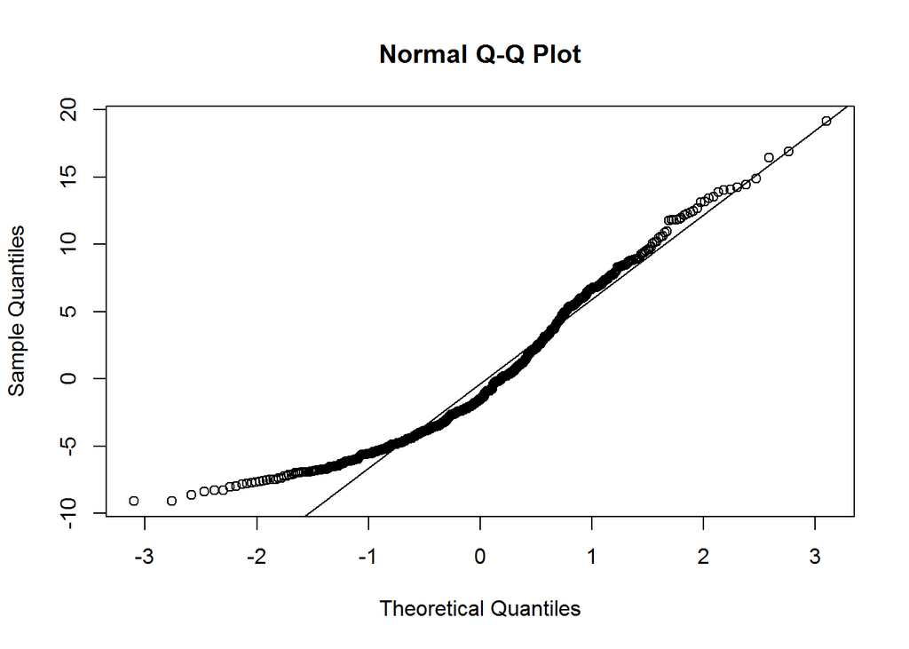

```r
qqnorm(residuals(lm5))
qqline(residuals(lm5))
```

Mate Value Test 2 (Mate Value Inventory - Kirsner et al 2003)

MV2 + Age + Selfscore*gender ANOVA

```r
VorNVMV2 <- lm(MV2Average ~ Age + Gender + Selfscore + Selfscore*Gender + Selfscore*Age, data = data)
anova(VorNVMV2, test="Chisq")
```

```
## Analysis of Variance Table
##
## Response: MV2Average
##                   Df Sum Sq Mean Sq F value  Pr(>F)
## Age                1   3.44  3.4375  4.1229 0.04282 *
## Gender             1   0.66  0.6553  0.7859 0.37576
## Selfscore          1   1.83  1.8333  2.1989 0.13873
## Gender:Selfscore   1   3.72  3.7164  4.4574 0.03523 *
## Age:Selfscore      1   0.01  0.0141  0.0169 0.89655
## Residuals        511 426.05  0.8338
## ---
## Signif. codes:  0 '***' 0.001 '**' 0.01 '*' 0.05 '.' 0.1 ' ' 1
```

Plot MV 2 and selfscore :

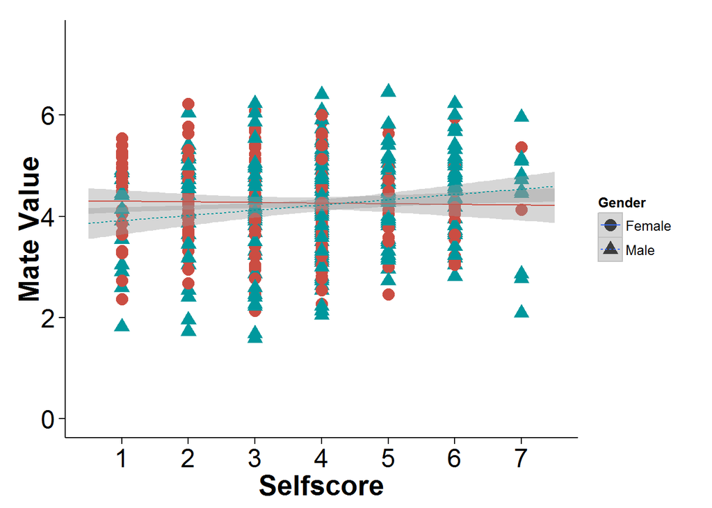

```r
plotMvAverageselfs <- ggplot(data, aes(x = Selfscore, y = MV2Average, color = Gender, shape = Gender, linetype = Gender)) +
  geom_point(size = 4) +
  ylim(0,7.5) +
  scale_colour_hue(l=50, guide = FALSE) +
  scale_x_continuous(limits=c(0.5,7.5), breaks=c(1:7)) +
  theme_bw() + geom_smooth(method=lm,  fullrange=T) +
  xlab("Selfscore") +
  ylab("Mate Value") +
  theme(axis.line = element_line(colour = "black"),
        axis.text=element_text(size=18),
        axis.title=element_text(size=20,face="bold"),
        axis.title.y=element_text(vjust=0.25),
        axis.title.x=element_text(vjust=0.25),
        panel.grid.major = element_blank(),
        panel.grid.minor = element_blank(),
        panel.border = element_blank(),
        panel.background = element_blank())
plotMvAverageselfs
```

Plot MV2 and age

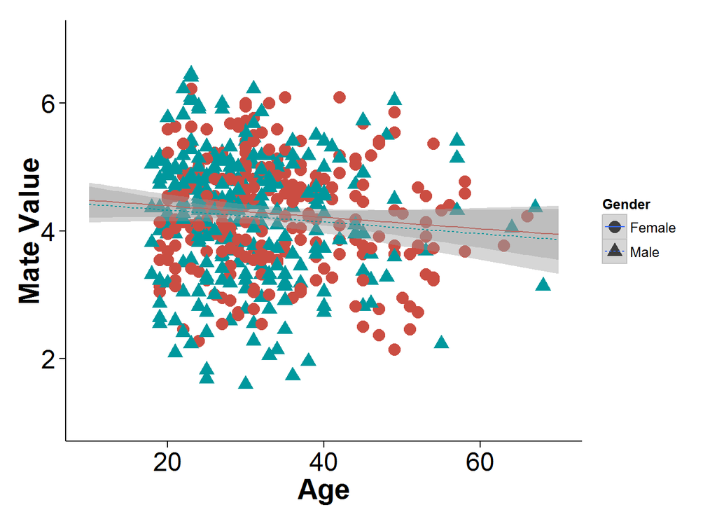

```r
plotmv2age <- ggplot(data, aes(x = Age, y = MV2Average, color = Gender, shape = Gender, linetype = Gender)) +
  geom_point(size = 4) +
  ylim(1,7) +
  scale_colour_hue(l=50, guide = FALSE) +
  scale_x_continuous(limits=c(10,70)) +
  theme_bw() + geom_smooth(method=lm,  fullrange=T) +
  xlab("Age") +
  ylab("Mate Value") +
  theme(legend.position="right") +
  theme(axis.line = element_line(colour = "black"),
        axis.text=element_text(size=18),
        axis.title=element_text(size=20,face="bold"),
        axis.title.y=element_text(vjust=0.25),
        axis.title.x=element_text(vjust=0.25),
        panel.grid.major = element_blank(),
        panel.grid.minor = element_blank(),
        panel.border = element_blank(),
        panel.background = element_blank())
plotmv2age
```

Sex Goal Activation (SGA)

SGA and AGE Plot

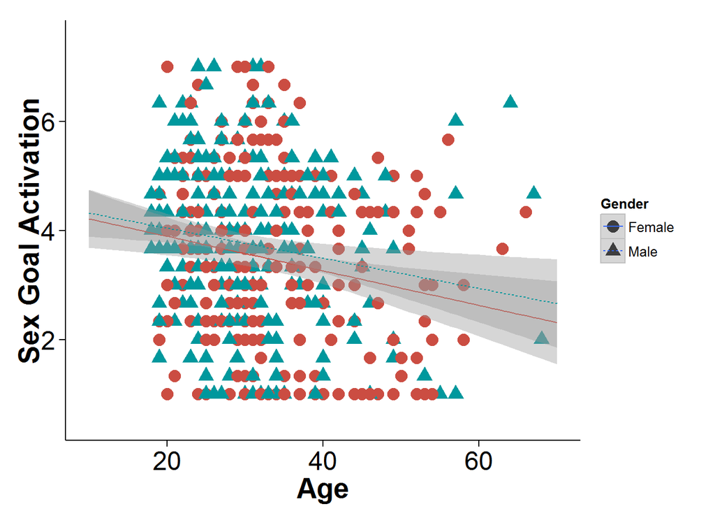

```r
plotsgaage <- ggplot(data, aes(x = Age, y = SGAAverage, color = Gender, shape = Gender, linetype = Gender)) +
  geom_point(size = 4) +
  ylim(0.5,7.5) +
  scale_colour_hue(l=50, guide = FALSE) +
  scale_x_continuous(limits=c(10,70)) +
  theme_bw() + geom_smooth(method=lm,  fullrange=T) +
  xlab("Age") +
  ylab("Sex Goal Activation") +
  theme(legend.position="right") +
  theme(axis.line = element_line(colour = "black"),
        axis.text=element_text(size=18),
        axis.title=element_text(size=20,face="bold"),
        axis.title.y=element_text(vjust=0.25),
        axis.title.x=element_text(vjust=0.25),
        panel.grid.major = element_blank(),
        panel.grid.minor = element_blank(),
        panel.border = element_blank(),
        panel.background = element_blank())
plotsgaage
```

SOIR (Revised Sociosexual Orientation Inventory)

SOIR + Averagefrequencyviolence+Gender Regression

```r
fitSOI <- lm(SOIRTOTAL ~ Averagefrequencyviolence + Gender, data=data)
summary(fitSOI)
```

```
##
## Call:
## lm(formula = SOIRTOTAL ~ Averagefrequencyviolence + Gender, data = data)
##
## Residuals:
##     Min      1Q  Median      3Q     Max
## -29.723 -11.016  -1.905   9.968  33.865
##
## Coefficients:
##                          Estimate Std. Error t value Pr(>|t|)
## (Intercept)               27.2045     1.2172  22.349  < 2e-16 ***
## Averagefrequencyviolence   0.1329     0.0696   1.909   0.0568 .
## GenderMale                 8.5688     1.2841   6.673 6.51e-11 ***
## ---
## Signif. codes:  0 '***' 0.001 '**' 0.01 '*' 0.05 '.' 0.1 ' ' 1
##
## Residual standard error: 13.92 on 514 degrees of freedom
## Multiple R-squared:  0.1065, Adjusted R-squared:  0.103
## F-statistic: 30.63 on 2 and 514 DF,  p-value: 2.704e-13
```

Plot of exposure to violence on SOIR

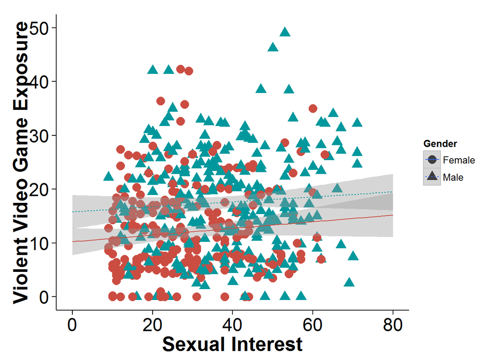

```r
plotSOI1 <- ggplot(data, aes(x = SOIRTOTAL, y = Averagefrequencyviolence, color = Gender, shape = Gender, linetype = Gender)) +
  geom_point(size=4) +
  ylim(0,50) +
  scale_colour_hue(l=50, guide = FALSE) +
  scale_x_continuous(limits=c(0,80)) +
  theme_bw() + geom_smooth(method=lm,  fullrange=T) +
  xlab("Sexual Interest") +
  ylab("Violent Video Game Exposure") +
  theme(legend.position="right") +
  theme(axis.line = element_line(colour = "black"),
        axis.text=element_text(size=18),
        axis.title=element_text(size=20,face="bold"),
        axis.title.y=element_text(vjust=0.25),
        axis.title.x=element_text(vjust=0.25),
        panel.grid.major = element_blank(),
        panel.grid.minor = element_blank(),
        panel.border = element_blank(),
        panel.background = element_blank())
plotSOI1
```

SOIR Age and Gender Plot

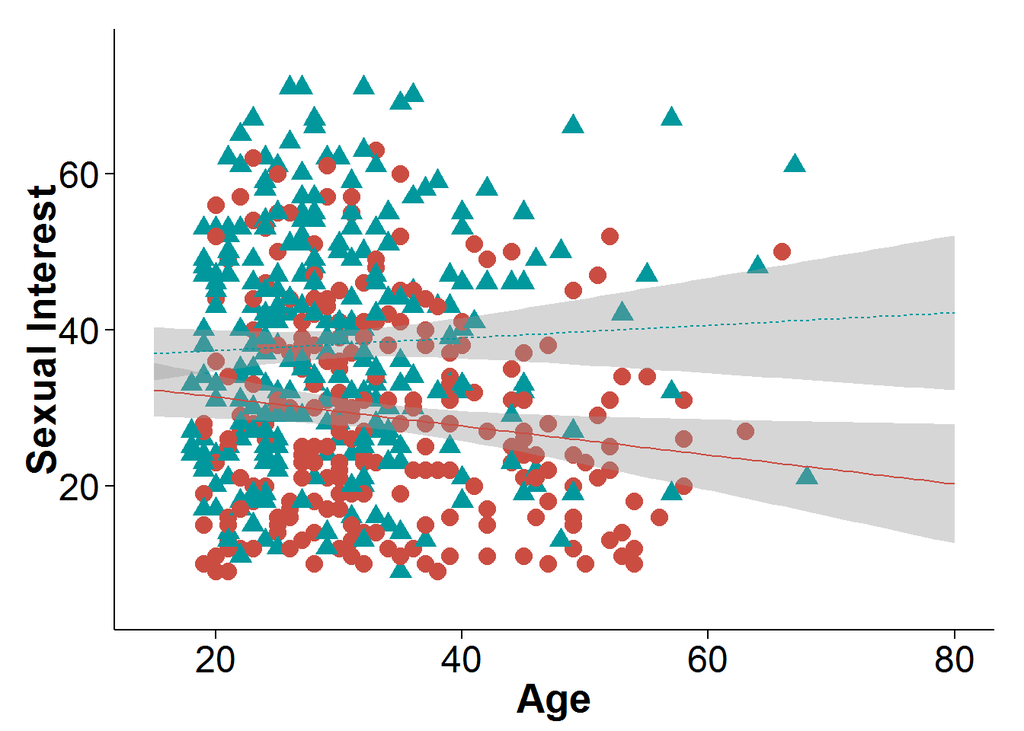

```r
plotSOI2 <- ggplot(data, aes(x = Age, y = SOIRTOTAL, color = Gender, shape = Gender, linetype = Gender)) +
  geom_point(size=4) +
  ylim(5,75) +
  scale_colour_hue(l=50, guide = FALSE) +
  scale_x_continuous(limits=c(15,80)) +
  theme_bw() + geom_smooth(method=lm,  fullrange=T) +
  xlab("Age") +
  ylab("Sexual Interest") +
  theme(legend.position="none") +
  theme(axis.line = element_line(colour = "black"),
        axis.text=element_text(size=18),
        axis.title=element_text(size=20,face="bold"),
        axis.title.y=element_text(vjust=0.25),
        axis.title.x=element_text(vjust=0.25),
        panel.grid.major = element_blank(),
        panel.grid.minor = element_blank(),
        panel.border = element_blank(),
        panel.background = element_blank())
plotSOI2
```

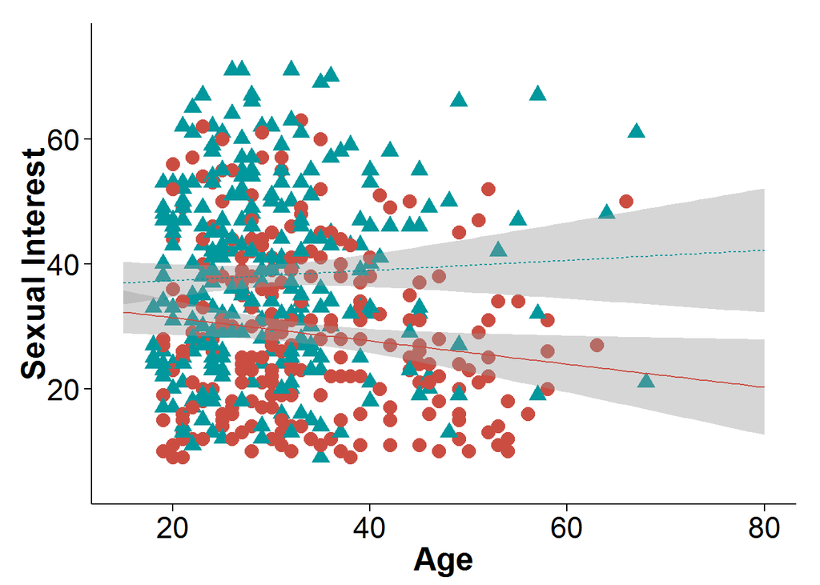

```r
plotSOI3 <- ggplot(data, aes(x = Age, y = SOIRTOTAL, color = Gender, shape = Gender, linetype = Gender)) +
  geom_point(size=4) +
  ylim(5,75) +
  scale_colour_hue(l=50, guide = FALSE) +
  scale_x_continuous(limits=c(15,80)) +
  theme_bw() + geom_smooth(method=lm,  fullrange=T) +
  xlab("Age") +
  ylab("Sexual Interest") +
  theme(legend.position="none") +
  theme(axis.line = element_line(colour = "black"),
        axis.text=element_text(size=18),
        axis.title=element_text(size=20,face="bold"),
        axis.title.y=element_text(vjust=0.25),
        axis.title.x=element_text(vjust=0.25),
        panel.grid.major = element_blank(),
        panel.grid.minor = element_blank(),
        panel.border = element_blank(),
        panel.background = element_blank())
plotSOI2
```

MATE VALUE TEST 1 AND MATING MOTIVATION TESTS : (TO REMOVE) Mate Value Test 1 (4-Item Mate Value Scale, Edlund and Sagarin 2014)

MV1 + gender + selfscore ANOVA*

```r
MV1selfscore <- lm(MV1Total ~  Gender+ Selfscore + Selfscore*Gender, data = data)
anova(MV1selfscore, test="Chisq")
```

```
## Analysis of Variance Table
##
## Response: MV1Total
##                   Df  Sum Sq Mean Sq F value    Pr(>F)
## Gender             1    50.2   50.19  2.0522    0.1526
## Selfscore          1   416.0  416.02 17.0104 4.336e-05 ***
## Gender:Selfscore   1    28.5   28.47  1.1643    0.2811
## Residuals        513 12546.2   24.46
## ---
## Signif. codes:  0 '***' 0.001 '**' 0.01 '*' 0.05 '.' 0.1 ' ' 1
```

MV1 x selfscore x gender plot

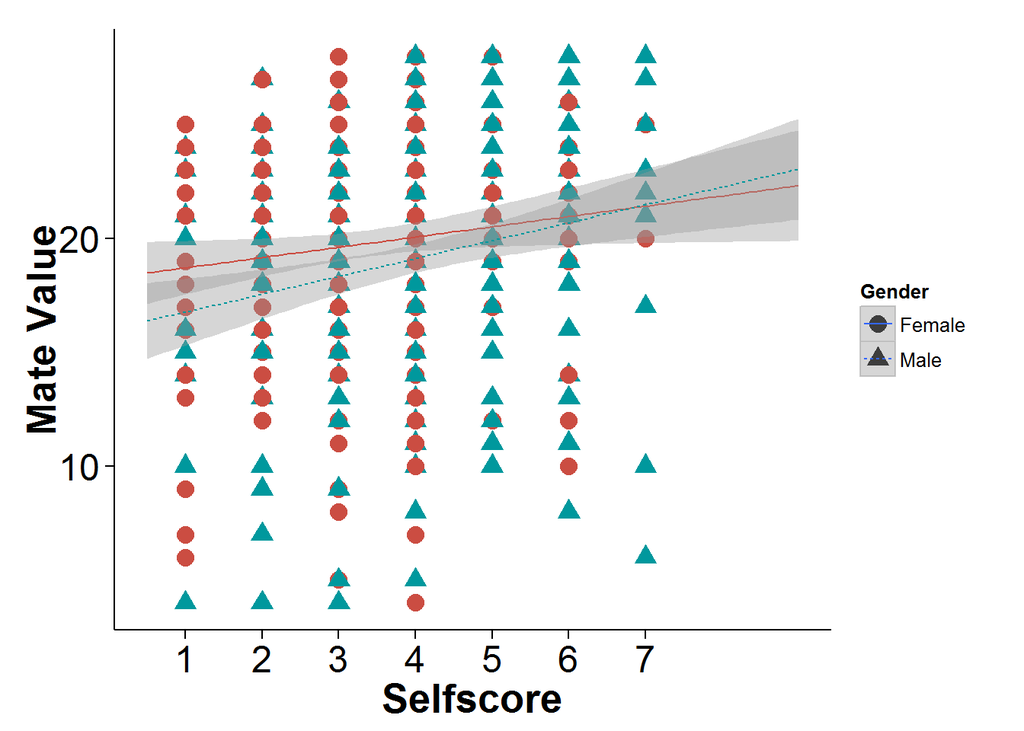

```r
plotMv1selfs <-ggplot(data, aes(x = Selfscore, y = MV1Total, color = Gender, shape = Gender, linetype = Gender)) +
  geom_point(size = 4) +
  scale_colour_hue(l=50, guide = FALSE) +
  scale_x_continuous(limits=c(0.5,9), breaks=c(1:7)) +
  theme_bw() + geom_smooth(method=lm,  fullrange=T) +
  xlab("Selfscore") +
  ylab("Mate Value") +
  theme(axis.line = element_line(colour = "black"),
        axis.text=element_text(size=18),
        axis.title=element_text(size=20,face="bold"),
        axis.title.y=element_text(vjust=0.25),
        axis.title.x=element_text(vjust=0.25),
        panel.grid.major = element_blank(),
        panel.grid.minor = element_blank(),
        panel.border = element_blank(),
        panel.background = element_blank())
plotMv1selfs
```

Mating motivation:

Matingmotivation + gender + selfscore + Violence exposure ANOVA

```r
MMANOVAVVG <- lm(MATINGMOTIVATIONtotal ~  Gender + Gender*Averagefrequencyviolence + Averagefrequencyviolence + Selfscore + Selfscore*Gender, data = data)
anova(MMANOVAVVG, test="Chisq")
```

```
## Analysis of Variance Table
##
## Response: MATINGMOTIVATIONtotal
##                                  Df  Sum Sq Mean Sq F value    Pr(>F)
## Gender                            1   157.9  157.87  4.7960 0.0289774 *
## Averagefrequencyviolence          1  1044.8 1044.77 31.7401 2.915e-08 ***
## Selfscore                         1   197.2  197.21  5.9913 0.0147124 *
## Gender:Averagefrequencyviolence   1   460.8  460.80 13.9991 0.0002036 ***
## Gender:Selfscore                  1     6.9    6.87  0.2087 0.6479558
## Residuals                       511 16820.2   32.92
## ---
## Signif. codes:  0 '***' 0.001 '**' 0.01 '*' 0.05 '.' 0.1 ' ' 1
```

Plot Matingmoviation and selfscore

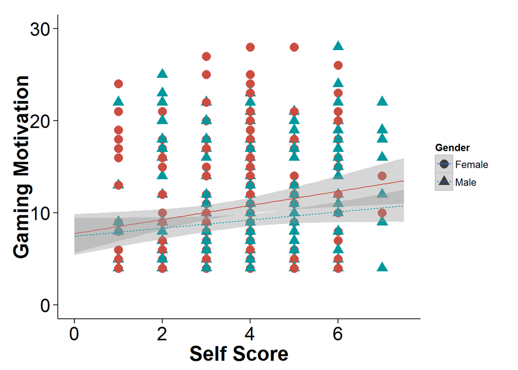

```r
plotmmselfscore <- ggplot(data, aes(x = Selfscore, y = MATINGMOTIVATIONtotal, color = Gender, shape = Gender, linetype = Gender)) +
  geom_point(size=4) +
  ylim(0,30) +
  scale_colour_hue(l=50, guide = FALSE) +
  scale_x_continuous(limits=c(0,7.5)) +
  theme_bw() + geom_smooth(method=lm,  fullrange=T) +
  xlab("Self Score") +
  ylab("Gaming Motivation") +
  theme(legend.position="right") +
  theme(axis.line = element_line(colour = "black"),
        axis.text=element_text(size=18),
        axis.title=element_text(size=20,face="bold"),
        axis.title.y=element_text(vjust=0.25),
        axis.title.x=element_text(vjust=0.25),
        panel.grid.major = element_blank(),
        panel.grid.minor = element_blank(),
        panel.border = element_blank(),
        panel.background = element_blank())
plotmmselfscore
```